# Python Regression Based Analysis

**Regression Based Analysis**  
**by: Juan Duran, Business Analyst & Industrial Engineer**

**Case Summary:**  
After three years serving customers across the San Francisco Bay Area, the executives at Apprentice Chef have come to realize that over 90% of their revenue comes from customers that have been ordering meal sets for 12 months or less. Given this information & dataset, they would like to better understand how much revenue to expect from each customer within their first year of orders. Thus, they have hired you on a full-time contract to analyze their data, develop your top insights, and build a machine learning model to predict revenue over the first year of each customer’s life cycle.

**My Process Summary:**

1. Understanding the problem
2. Loading programming tools:
1. Importing packages
2. Declaring function
3. Executing classes
3. Importing Dataset
4. Data Cleaning & exploration:
1. Observing dataset content
2. Imputing null values
3. Identifying trends
5. Feature Engineering:
1. Categorical variables
2. Numerical variables
3. Observing patterns
6. Building the model:
1. Ordinary Least Squared Model
2. Training and testing
3. Testing multiple predictive Model
7. Selecting best predictive Model

**1. Understanding the problem**  
This problem consists in building a model to predict revenue based on other variables. The goal is to identify predictions on at least 90% of the holdout data (25% of the dataset).

**2. Loading programming tools**

```python
# Student Name : Juan Duran
# Cohort       : FMSBA2 - Haight

import warnings
warnings.simplefilter("ignore")
################################################################################
# Import Packages
################################################################################

def libraries():
    import pandas as pd
    import matplotlib.pyplot as plt
    import seaborn as sns
    import statsmodels.formula.api as smf
    from sklearn.model_selection import train_test_split
    from sklearn.linear_model import LinearRegression
    import sklearn.linear_model
    import pandasql
    import math
    from sklearn.linear_model import LogisticRegression
    from sklearn.metrics import confusion_matrix
    from sklearn.metrics import roc_auc_score
    from sklearn.neighbors import KNeighborsClassifier
    from sklearn.neighbors import KNeighborsRegressor
    from sklearn.preprocessing import StandardScaler

    from sklearn.tree import DecisionTreeClassifier
    from sklearn.tree import export_graphviz
    from sklearn.externals.six import StringIO
    from IPython.display import Image
    import pydotplus
    import warnings
    from colorama import Fore, Back, Style
    from sklearn.ensemble import RandomForestClassifier     # random forest
    from sklearn.ensemble import GradientBoostingClassifier # gbm
    import statistics
    from decimal import Decimal
    from scipy import stats
    from sklearn.ensemble import GradientBoostingRegressor

    global pd, plt, sns, smf, train_test_split, LinearRegression, sklearn, linear_model, pandasql, math
    global metrics, neighbors, preprocessing, LogisticRegression, confusion_matrix, roc_auc_score
    global KNeighborsClassifier, KNeighborsRegressor, StandardScaler
    global graphviz, tree, externals, six, IPython, display, DecisionTreeClassifier, export_graphviz, StringIO, Image, pydotplus
    global warnings, colorama, Fore, Back, Style
    global ensemble, RandomForestClassifier, GradientBoostingClassifier, statistics, decimal, Decimal, stats
    global GradientBoostingRegressor
libraries()

################################################################################
# Declaring Global vairables
################################################################################
global model_performance
model_performance = []

class color:
   PURPLE = '\033[95m'
   CYAN = '\033[96m'
   DARKCYAN = '\033[36m'
   BLUE = '\033[94m'
   GREEN = '\033[92m'
   YELLOW = '\033[93m'
   RED = '\033[91m'
   BOLD = '\033[1m'
   UNDERLINE = '\033[4m'
   END = '\033[0m'

def optimal_neighbors(X_data,y_data,standardize = True,pct_test=0.25,seed=802,response_type='reg', max_neighbors=20,show_viz=True):
    if standardize == True:
        scaler = StandardScaler()
        scaler.fit(X_data)
        X_scaled = scaler.transform(X_data)
        X_scaled_df = pd.DataFrame(X_scaled)
        X_data = X_scaled_df



    # train-test split
    X_train, X_test, y_train, y_test = train_test_split(X_data, y_data, test_size = pct_test, random_state = seed)


    # creating lists for training set accuracy and test set accuracy
    training_accuracy = []
    test_accuracy = []


    # setting neighbor range
    neighbors_settings = range(1, max_neighbors + 1)


    for n_neighbors in neighbors_settings:
        # building the model based on response variable type
        if response_type == 'reg':
            clf = KNeighborsRegressor(n_neighbors = n_neighbors)
            clf.fit(X_train, y_train)

        elif response_type == 'class':
            clf = KNeighborsClassifier(n_neighbors = n_neighbors)
            clf.fit(X_train, y_train)

        else:
            print("Error: response_type must be 'reg' or 'class'")

        training_accuracy.append(clf.score(X_train, y_train))
        test_accuracy.append(clf.score(X_test, y_test))


    # optionally displaying visualization
    if show_viz == True:
        # plotting the visualization
        fig, ax = plt.subplots(figsize=(12,8))
        plt.plot(neighbors_settings, training_accuracy, label = "training accuracy")
        plt.plot(neighbors_settings, test_accuracy, label = "test accuracy")
        plt.ylabel("Accuracy")
        plt.xlabel("n_neighbors")
        plt.legend()
        plt.show()


    # returning optimal number of neighbors
    print(f"The optimal number of neighbors is: {test_accuracy.index(max(test_accuracy))+1}")
    return test_accuracy.index(max(test_accuracy))+1

def display_tree(tree, feature_df, height, width):
    """
    PARAMETERS
    ----------
    tree       : fitted tree model object
        fitted CART model to visualized
    feature_df : DataFrame
        DataFrame of explanatory features (used to generate labels)
    height     : int, default 500
        height in pixels to which to constrain image in html
    width      : int, default 800
        width in pixels to which to constrain image in html
    """

    # visualizing the tree
    dot_data = StringIO()


    # exporting tree to graphviz
    export_graphviz(decision_tree      = tree,
                    out_file           = dot_data,
                    filled             = True,
                    rounded            = True,
                    special_characters = True,
                    feature_names      = feature_df.columns)


    # declaring a graph object
    graph = pydotplus.graph_from_dot_data(dot_data.getvalue())


    # creating image
    img = Image(graph.create_png(), height = height, width  = width)

    return img

def plot_feature_importances(model, train, size_x, size_y, title, export = False):
    """
    Plots the importance of features from a CART model.

    PARAMETERS
    ----------
    model  : CART model
    train  : explanatory variable training data
    export : whether or not to export as a .png image, default False
    """

    # declaring the number
    n_features = X_train.shape[1]

    # setting plot window
    fig, ax = plt.subplots(figsize=(size_x,size_y))

    plt.barh(range(n_features), model.feature_importances_, align='center')
    plt.yticks(pd.np.arange(n_features), train.columns)
    plt.xlabel("Feature importance")
    plt.ylabel("Feature")
    plt.title(title)

    if export == True:
        plt.savefig('Tree_Leaf_50_Feature_Importance.png')
```

**Class: juan_duran**  
This class contains functions I have created for the analysis. The code is not included. You can contact me if you would like to learn more about it.

```python
################################################################################
# Class: juan_duran. The content of my functions is not include,
# contact me if you would like to learn more.
################################################################################
class juan_duran:

    def data_view(df, n_rows, n_round):

    def data_classify(df, Classification, n_rows, n_round):

    def categ(df, response_col, listof_categories, max_cor, min_cor):

    def numerical(df, response_col, max_cor, min_cor, n_rows):

    def Highest_cor(df, response_var, max1, min1, n_rows):

    def view_hist(df, list1, print_img, size_x, size_y, font_size):

    def view_normality(df, list1, print_img, size_x, size_y, font_size):

    def view_scat(df, list1, response_var, print_img, size_x, size_y, font_size, green_blue = "g"):

    def test_dist_edits(df, dict_out_hi, dict_out_lo, corr_max, corr_min, n_rows, explanatory_var):

    def test_scatter_edits(df, dict_out_hi, dict_out_lo, corr_max, corr_min, n_rows, explanatory_var):

    def OLS_Regression(df, response_var, max1, min1, n_rows):

    def train_test(df, response_var, max1, min1, test_size, rand_state, n_rows):

    def train_test_list(df, response_var, max1, min1, test_size, rand_state, n_rows, list_explanatory):

    def linear_models_table(X_train, X_test, y_train, y_test):

    def one_hot(df, response_var, exp_var, n_rows):

    def one_hot_join_remove(df, df_one_hot, hot_list, var_remove):

    def train_test_smflogit(df, response_var, list_high_corr):

    def train_test_logisticReg(df, response_var, list_high_corr):

    def confusionM(y_test, logreg_pred, var_name):

    def train_test_knn(df, response_var, list_high_corr):

    def model_results_add(name_model, list_add):

    def tree_classifier(X_train, y_train, X_test, y_test):

    def tree_pruner(X_train, y_train, X_test, y_test):
juan_duran
```

```
__main__.juan_duran
```

**3. Importing Dataset**

```python
file = 'Apprentice_Chef_Dataset.xlsx'
original_df = pd.read_excel(file)
df = original_df
print(color.GREEN + "Data Loaded ok" + color.END)
```

```
Data Loaded ok
```

**4. Data Cleaning & exploration**

```python
# Observing characteristics of data
juan_duran.data_view(df, 28, 2)
```

|  | VARIABLES | NULLS | COUNT | TYPES | MEAN | MEDIAN | UNIQUES | SAMPLE | Outliers | pval(Norm) |
| --- | --- | --- | --- | --- | --- | --- | --- | --- | --- | --- |
| 0 | REVENUE | 0 | 1946 | float64 | 2107.29 | 1740.00 | 859 | [1880.0, 1495.0, 2572.5, 1647.0, 1923.0, 1250.... | [0,82] | 7e-28 |
| 1 | CROSS_SELL_SUCCESS | 0 | 1946 | int64 | 0.68 | 1.00 | 2 | [1, 1, 1, 1, 1, 1, 1, 1, 1, 1] |  | 4e-152 |
| 2 | NAME | 0 | 1946 | object | NaN | NaN | 1946 | ['Addam Osgrey', 'Aegon Blackfyre', 'Aegon Fre... |  | 0 |
| 3 | EMAIL | 0 | 1946 | object | NaN | NaN | 1946 | ['addam.osgrey@passport.com', 'aegon.blackfyre... |  | 0 |
| 4 | FIRST_NAME | 0 | 1946 | object | NaN | NaN | 1442 | ['Addam', 'Aegon', 'Aegon', 'Aegon', 'Aegon', ... |  | 0 |
| 5 | FAMILY_NAME | 47 | 1899 | object | NaN | NaN | 1070 | ['Osgrey', 'Blackfyre', 'Frey ', 'Targaryen ',... |  | 0 |
| 6 | TOTAL_MEALS_ORDERED | 0 | 1946 | int64 | 74.63 | 60.00 | 230 | [118, 44, 38, 76, 65, 57, 106, 122, 46, 58] | [0,107] | 3e-14 |
| 7 | UNIQUE_MEALS_PURCH | 0 | 1946 | int64 | 4.90 | 5.00 | 15 | [4, 3, 1, 3, 3, 4, 3, 6, 4, 4] | [0,2] | 6e-10 |
| 8 | CONTACTS_W_CUSTOMER_SERVICE | 0 | 1946 | int64 | 6.98 | 7.00 | 15 | [7, 6, 5, 8, 6, 6, 10, 8, 5, 6] | [0,3] | 5e-19 |
| 9 | PRODUCT_CATEGORIES_VIEWED | 0 | 1946 | int64 | 5.38 | 5.00 | 10 | [5, 3, 3, 10, 9, 2, 8, 10, 10, 5] |  | 7e-19 |
| 10 | AVG_TIME_PER_SITE_VISIT | 0 | 1946 | float64 | 99.60 | 94.16 | 1454 | [86.0, 125.6, 58.0, 45.51, 106.0, 84.21, 110.0... | [0,87] | 3e-23 |
| 11 | MOBILE_NUMBER | 0 | 1946 | int64 | 0.88 | 1.00 | 2 | [1, 1, 1, 0, 1, 1, 1, 1, 1, 1] |  | 4e-182 |
| 12 | CANCELLATIONS_BEFORE_NOON | 0 | 1946 | int64 | 1.40 | 1.00 | 12 | [2, 0, 5, 3, 1, 0, 3, 1, 0, 0] | [0,44] | 4e-54 |
| 13 | CANCELLATIONS_AFTER_NOON | 0 | 1946 | int64 | 0.17 | 0.00 | 4 | [1, 1, 0, 0, 1, 0, 0, 0, 0, 1] | [0,279] | 2e-221 |
| 14 | TASTES_AND_PREFERENCES | 0 | 1946 | int64 | 0.71 | 1.00 | 2 | [0, 0, 1, 1, 0, 1, 0, 1, 1, 1] |  | 1e-171 |
| 15 | MOBILE_LOGINS | 0 | 1946 | int64 | 5.52 | 6.00 | 4 | [6, 6, 6, 6, 6, 5, 6, 5, 6, 6] |  | 5e-10 |
| 16 | PC_LOGINS | 0 | 1946 | int64 | 1.48 | 1.00 | 4 | [2, 1, 2, 1, 2, 1, 2, 1, 2, 2] |  | 5e-95 |
| 17 | WEEKLY_PLAN | 0 | 1946 | int64 | 11.33 | 7.00 | 53 | [8, 8, 14, 11, 12, 10, 7, 8, 8, 2] | [0,237] | 4e-49 |
| 18 | EARLY_DELIVERIES | 0 | 1946 | int64 | 1.49 | 0.00 | 10 | [0, 0, 0, 5, 0, 2, 0, 0, 4, 3] | [0,79] | 3e-99 |
| 19 | LATE_DELIVERIES | 0 | 1946 | int64 | 2.97 | 2.00 | 20 | [2, 4, 0, 4, 4, 5, 3, 3, 10, 7] | [0,96] | 4e-25 |
| 20 | PACKAGE_LOCKER | 0 | 1946 | int64 | 0.36 | 0.00 | 2 | [1, 1, 0, 0, 1, 0, 0, 0, 1, 1] |  | 1e-142 |
| 21 | REFRIGERATED_LOCKER | 0 | 1946 | int64 | 0.11 | 0.00 | 2 | [0, 0, 0, 0, 0, 0, 0, 0, 1, 1] |  | 2e-197 |
| 22 | FOLLOWED_RECOMMENDATIONS_PCT | 0 | 1946 | int64 | 35.41 | 30.00 | 10 | [90, 90, 80, 90, 90, 70, 70, 70, 70, 90] |  | 2e-32 |
| 23 | AVG_PREP_VID_TIME | 0 | 1946 | float64 | 150.56 | 145.60 | 1038 | [165.8, 150.5, 99.6, 125.0, 135.3, 91.2, 263.3... | [0,57] | 0.002 |
| 24 | LARGEST_ORDER_SIZE | 0 | 1946 | int64 | 4.44 | 4.00 | 12 | [6, 4, 3, 3, 3, 3, 6, 5, 4, 7] | [0,33] | 2e-23 |
| 25 | MASTER_CLASSES_ATTENDED | 0 | 1946 | int64 | 0.60 | 1.00 | 4 | [1, 1, 0, 0, 1, 1, 2, 1, 2, 1] | [0,6] | 1e-27 |
| 26 | MEDIAN_MEAL_RATING | 0 | 1946 | int64 | 2.79 | 3.00 | 5 | [3, 3, 3, 3, 3, 2, 4, 3, 3, 3] | [0,13] | 3e-06 |
| 27 | AVG_CLICKS_PER_VISIT | 0 | 1946 | int64 | 13.51 | 13.00 | 15 | [11, 13, 12, 13, 13, 17, 10, 13, 12, 12] | [6,0] | 0.03 |
| 28 | TOTAL_PHOTOS_VIEWED | 0 | 1946 | int64 | 106.43 | 0.00 | 371 | [0, 90, 0, 0, 253, 0, 705, 0, 0, 0] | [0,120] | 2e-87 |

**Imputation of data:**  
Replacing null values in data.

```python
df['FAMILY_NAME'] = df['FAMILY_NAME'].fillna('x')
```

**Identify trends**  
Look for patterns in data. Compare slopes to their equivalent normal distribution.

[figure not shown]

```python
list_analysis = ['AVG_CLICKS_PER_VISIT',
                 'TOTAL_MEALS_ORDERED',
                 'MEDIAN_MEAL_RATING',
                 'AVG_PREP_VID_TIME']
juan_duran.view_normality(df, list_analysis, 'n', 10, 30, 12)
```

**Example of observation:**  
From the histogram charts above, it is clear to see most meals have a rating of 2 and 3.  
It would be useful to learn more about customer experience in these ratings to improve overall ratings.

**5. Feature Engineering**

**Create new categorical variables:**  
I have categorized emails by domain name and domain type. My two domain types are Popular and Junk Mail. Categorical feature engineering consists in creating new variables that numerically represent each category. This process is designed to identify patterns and outliers in the data. You can see the process below.

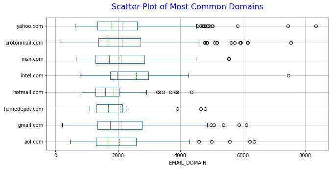

|  | EMAIL_DOMAIN | countx | DOMAIN_TYPE |
| --- | --- | --- | --- |
| 0 | homedepot.com | 17 | 0.0 |
| 1 | intel.com | 17 | 0.0 |
| 2 | cisco.com | 18 | 0.0 |
| 3 | goldmansacs.com | 18 | 0.0 |
| 4 | unitedtech.com | 18 | 0.0 |
| ... | ... | ... | ... |
| 34 | aol.com | 69 | 0.0 |
| 35 | msn.com | 72 | 0.0 |
| 36 | yahoo.com | 274 | 1.0 |
| 37 | protonmail.com | 284 | 1.0 |
| 38 | gmail.com | 303 | 1.0 |

39 rows × 3 columns

```python
email_categorical = []
for index, row in df[['EMAIL']].iterrows():
    email_categorical.append(row[0].partition("@")[2])

# new column
df['EMAIL_DOMAIN'] = email_categorical

# new column
df["DOMAIN_TYPE"] = 0
df["DOMAIN_TYPE"] = df['EMAIL_DOMAIN'].map({'gmail.com': 1, 'protonmail.com': 1, 'yahoo.com':1})
df["DOMAIN_TYPE"] = df["DOMAIN_TYPE"].fillna(0)

# B. Observe changes
pd.set_option('display.max_rows', 10)
domains_info = pandasql.sqldf("SELECT EMAIL_DOMAIN, count(*) as countx, avg(DOMAIN_TYPE) as DOMAIN_TYPE FROM df group by EMAIL_DOMAIN order by countx;", globals())

list_of_values = ['gmail.com', 'yahoo.com',
                  'protonmail.com', 'msn.com',
                  'aol.com', 'hotmail.com',
                  'homedepot.com', 'intel.com']

df_cat = df[df['EMAIL_DOMAIN'].isin(list_of_values)]


aa = df_cat.boxplot('REVENUE', 'EMAIL_DOMAIN', vert = False, patch_artist = False, meanline = True, showmeans = True, figsize = (10, 5))
plt.suptitle("Scatter Plot of Most Common Domains", fontsize = 16, color = 'b')
aa.get_figure().gca().set_title("")
plt.show()
domains_info
```

**Outliers for categorical variables:**  
I have designed a function to automate the search for outliers in a categorical data series.  
The following code executes a search for outliers in the Email Domain column.  
At the end, the process will generate a new numerical column to distinguish outliers.

```python
response_col = 'REVENUE'
listof_categories = ['EMAIL_DOMAIN']
juan_duran.categ(df, response_col, listof_categories, 0.001, -0.001)
```

|  | VAR | Lower_Limit | Upper_Limit | CORR |
| --- | --- | --- | --- | --- |
| 0 | out1_EMAIL_DOMAIN | 87.5 | 2577.0 | 0.8283 |

```python
dataF_cor, df_one_hot, hot_list = juan_duran.one_hot(df, 'REVENUE', 'EMAIL_DOMAIN', 6)
df = juan_duran.one_hot_join_remove(df, df_one_hot, hot_list, 'EMAIL_DOMAIN')
df[hot_list]
```

```
one_hots added and EMAIL_DOMAIN removed
```

|  | intel.com | exxon.com | visa.com | ge.org | walmart.com | jnj.com |
| --- | --- | --- | --- | --- | --- | --- |
| 0 | 0 | 0 | 0 | 0 | 0 | 0 |
| 1 | 0 | 0 | 0 | 0 | 0 | 1 |
| 2 | 0 | 0 | 0 | 0 | 0 | 0 |
| ... | ... | ... | ... | ... | ... | ... |
| 1943 | 0 | 0 | 0 | 0 | 0 | 0 |
| 1944 | 0 | 0 | 0 | 0 | 0 | 0 |
| 1945 | 0 | 0 | 0 | 0 | 0 | 0 |

1946 rows × 6 columns

**Identify outliers from numerical variables:**  
The following code looks for outliers and generates new columns to represent them.

```python
response_col = 'REVENUE'
outlier_correl = juan_duran.numerical(df, response_col, 0.04, -0.04, 8)
outlier_correl
```

|  | VAR | Lower_Limit | Upper_Limit | CORR |
| --- | --- | --- | --- | --- |
| 0 | out2_AVG_CLICKS_PER_VISIT | 7.50 | 10.4000 | -0.4988 |
| 1 | out2_UNIQUE_MEALS_PURCH | -3.00 | 9.4000 | 0.1705 |
| 2 | out2_CONTACTS_W_CUSTOMER_SERVICE | 0.50 | 6.5500 | 0.2708 |
| 3 | out2_AVG_TIME_PER_SITE_VISIT | 4.07 | 103.4565 | 0.2523 |
| 4 | out2_TOTAL_PHOTOS_VIEWED | -261.00 | 195.0000 | 0.4150 |
| 5 | out2_TOTAL_MEALS_ORDERED | -45.00 | 58.5000 | 0.4804 |
| 6 | out2_AVG_PREP_VID_TIME | 25.34 | 156.6800 | 0.5237 |
| 7 | out2_REVENUE | -630.00 | 2484.3125 | 0.8276 |

**View variables with highest correlation**  
Variables containing out2_ or out1_ in their name are new generated variables.

```python
cor_df, list_high_corr = juan_duran.Highest_cor(df, 'REVENUE', 0.45, -0.45, 25)
cor_df
```

|  | VAR | COR |
| --- | --- | --- |
| 40 | AVG_CLICKS_PER_VISIT | -0.5538 |
| 39 | out2_AVG_CLICKS_PER_VISIT | -0.4988 |
| 8 | TOTAL_PHOTOS_VIEWED | 0.4660 |
| 7 | out2_TOTAL_MEALS_ORDERED | 0.4804 |
| 6 | out2_AVG_PREP_VID_TIME | 0.5237 |
| 5 | TOTAL_MEALS_ORDERED | 0.6005 |
| 4 | MEDIAN_MEAL_RATING | 0.6079 |
| 3 | AVG_PREP_VID_TIME | 0.6436 |
| 2 | out2_REVENUE | 0.8276 |
| 1 | out1_EMAIL_DOMAIN | 0.8283 |

**Observing patterns in data**

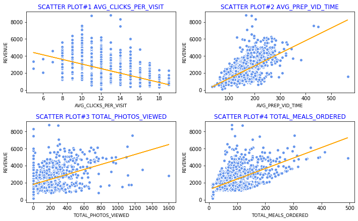

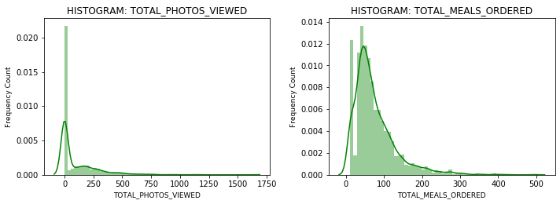

```python
# Observing characteristics of data
list_analysis = ['AVG_CLICKS_PER_VISIT', 'AVG_PREP_VID_TIME', 'TOTAL_PHOTOS_VIEWED', 'TOTAL_MEALS_ORDERED']
juan_duran.view_scat(df, list_analysis, 'REVENUE', 'n', 10, 30, 12, "blue")
# Observing characteristics of data
list_analysis = ['TOTAL_PHOTOS_VIEWED', 'TOTAL_MEALS_ORDERED']
juan_duran.view_hist(df, list_analysis, 'n', 10, 20, 12)
```